# Лабораторная Работа №5

Эмуляция и измерение потерь пакетов в глобальных сетях

Козлов В.П.

Российский университет дружбы народов им. Патриса Лумумбы, Москва, Россия

## Докладчик

- Козлов Всеволод Павлович
- НФИбд-02-22
- Российский университет дружбы народов
- [1132226428@pfur.ru]

# Выполнение лабораторной работы

## Цель работы

Основной целью работы является получение навыков проведения интерактивных экспериментов в среде Mininet по исследованию параметров сети, связанных с потерей, дублированием, изменением порядка и повреждением пакетов при передаче данных. Эти параметры влияют на производительность протоколов и сетей.

## Задание

1. Задайте простейшую топологию, состоящую из двух хостов и коммутатора с назначенной по умолчанию mininet сетью 10.0.0.0/8.
2. Проведите интерактивные эксперименты по по исследованию параметров сети, связанных с потерей, дублированием, изменением порядка и повреждением пакетов при передаче данных.
3. Реализуйте воспроизводимый эксперимент по добавлению правила отбрасывания пакетов в эмулируемой глобальной сети. На экран выведите сводную информацию о потерянных пакетах.
4. Самостоятельно реализуйте воспроизводимые эксперименты по исследованию параметров сети, связанных с потерей, изменением порядка и повреждением пакетов при передаче данных. На экран выведите сводную информацию о потерянных пакетах.

## Задал простейшую топологию, просмотрел ifconfig

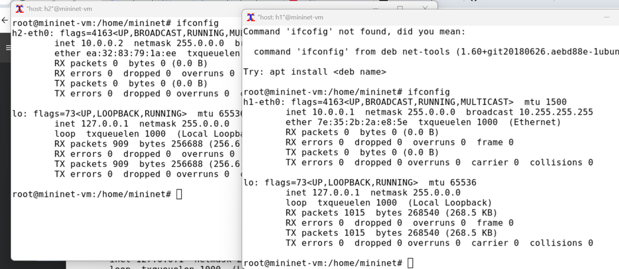

ifconfig

## Пропинговал

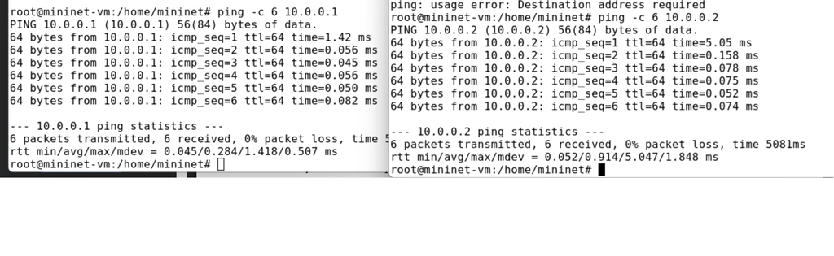

Пингование

## На h1 добавил 10% потерь пакетов

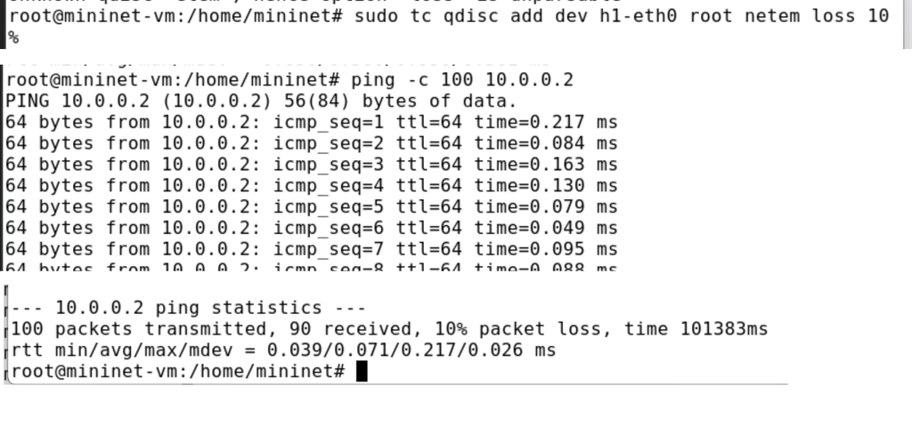

На h1 10% потерь пакетов

## На h2 тоже добавил 10% потерь пакетов

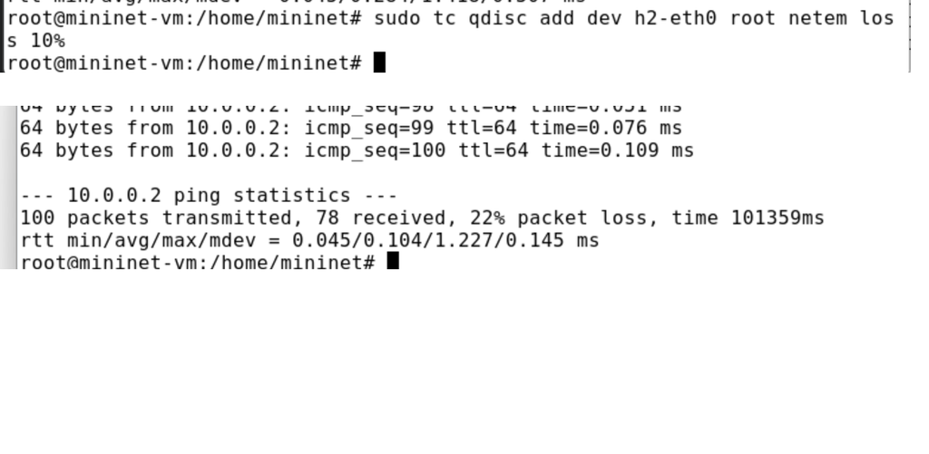

На h2 тоже 10% потерь пакетов

## Добавил на интерфейсе узла h1 коэффициент потери пакетов 50%

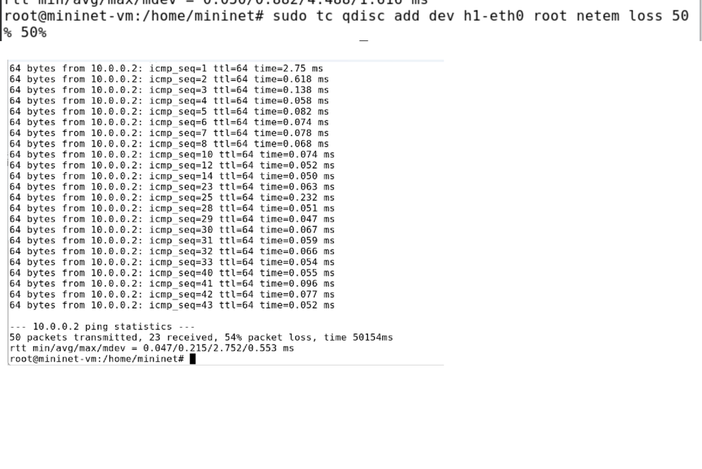

На интерфейсе узла h1 коэффициент потери пакетов 50%

## Добавил на интерфейсе узла h1 0,01% повреждения пакетов

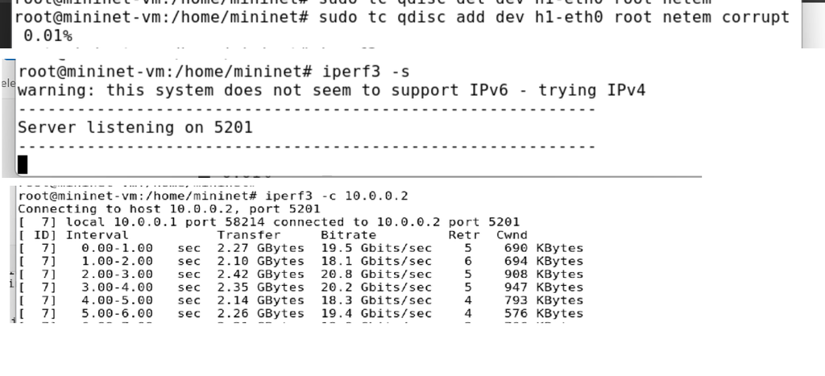

На интерфейсе узла h1 0,01% повреждения пакетов

## 25% пакетов - сразу, остальные - с задержкой

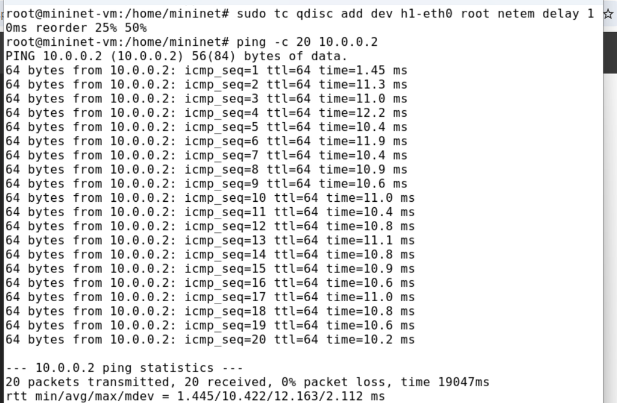

25% пакетов - сразу, остальные - с задержкой

## h1 задал правило c дублированием 50% пакетов

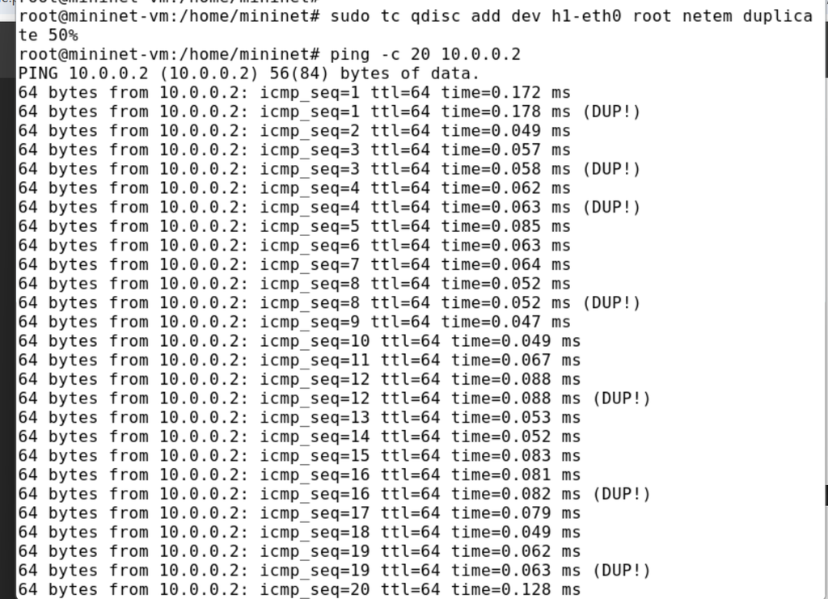

Правило c дублированием 50% пакетов

## Написал скрипт

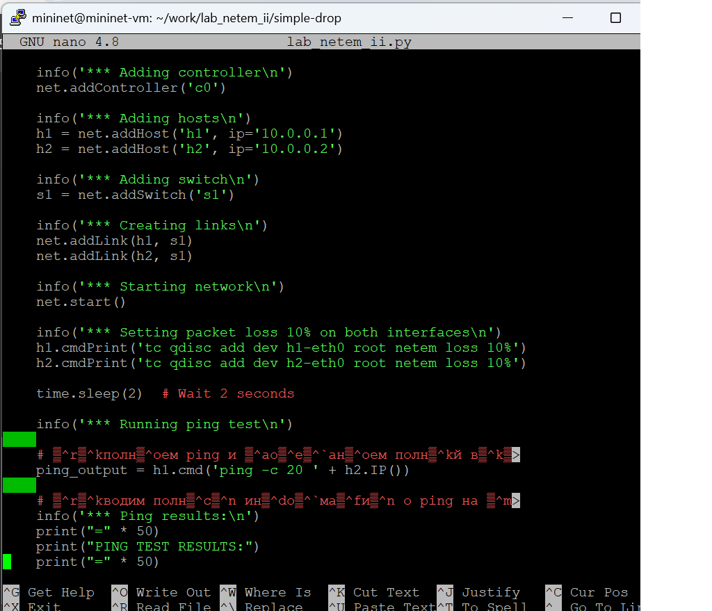

python скрипт

## Создал Makefile

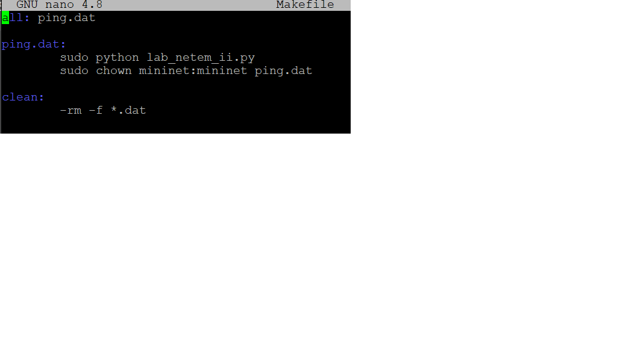

Makefile

## Зпуск make

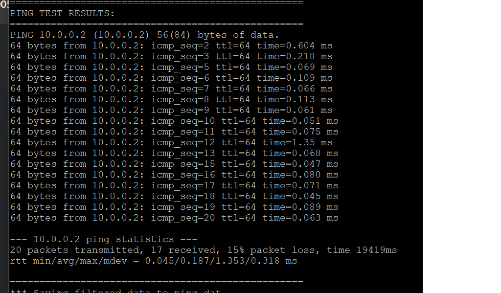

Зпуск make

## Написал lab_netem_loss.py

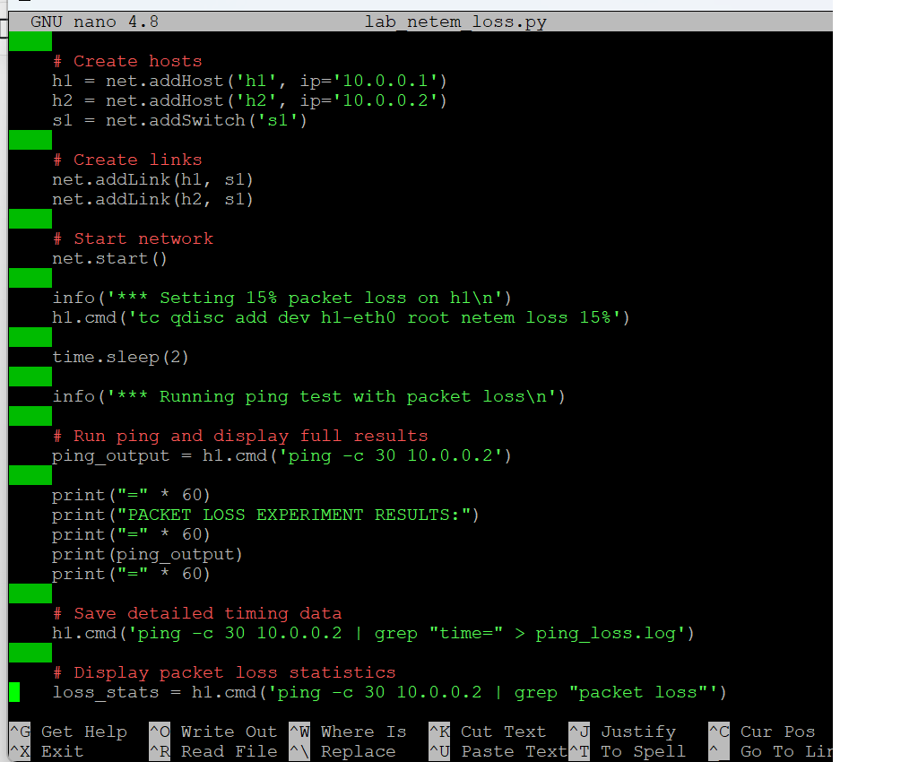

lab_netem_loss.py

## Запуск lab_netem_loss.py

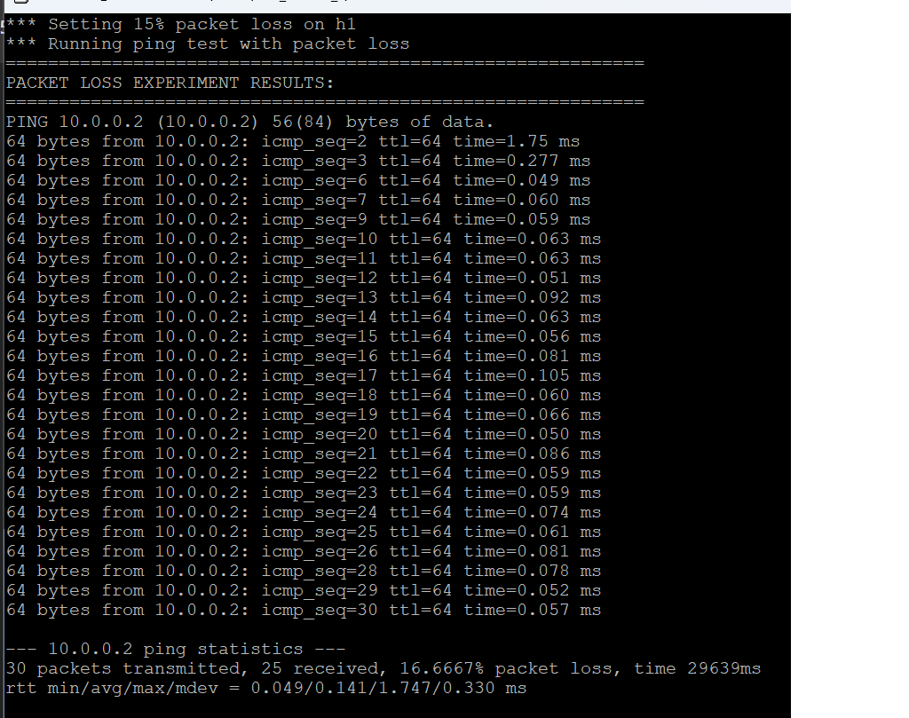

Запуск lab_netem_loss.py

## Написал lab_netem_reorder.py

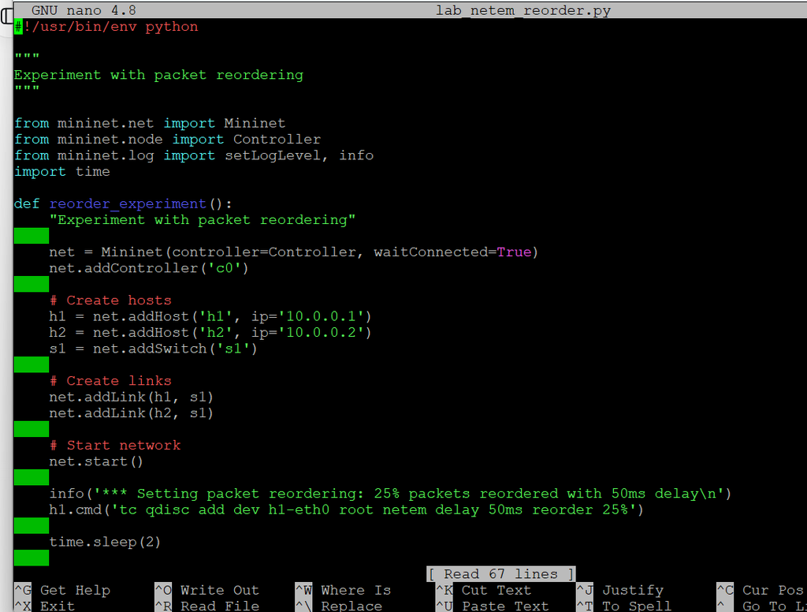

lab_netem_reorder.py

## Запуск lab_netem_reorder.py

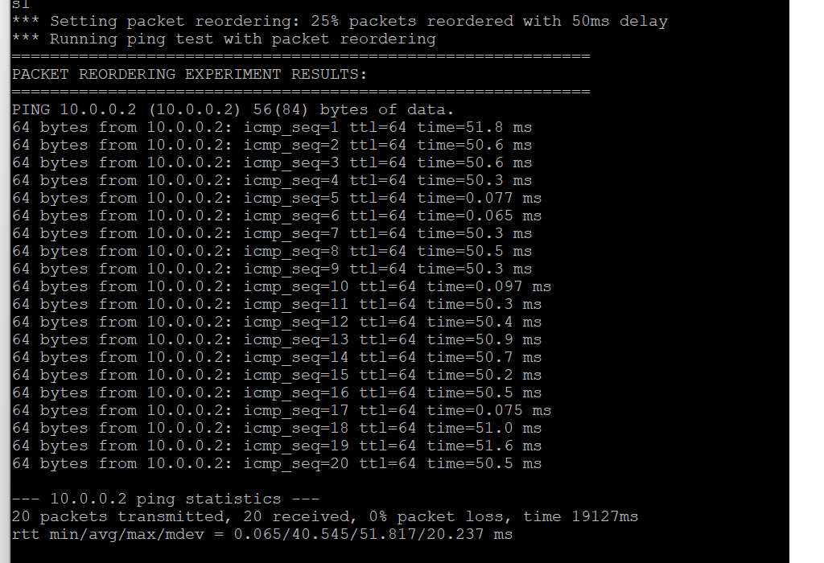

Запуск lab_netem_reorder.py

## Написал lab_netem_corruption.py

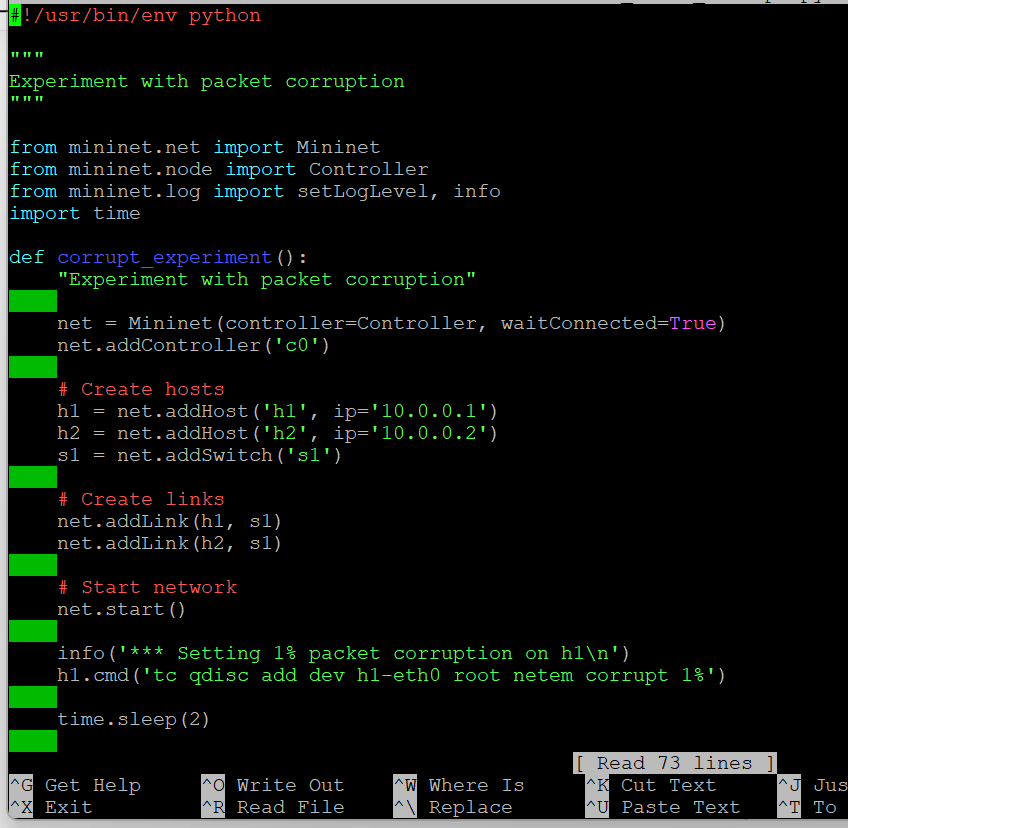

lab_netem_corruption.py

## Запуск lab_netem_corruption.py

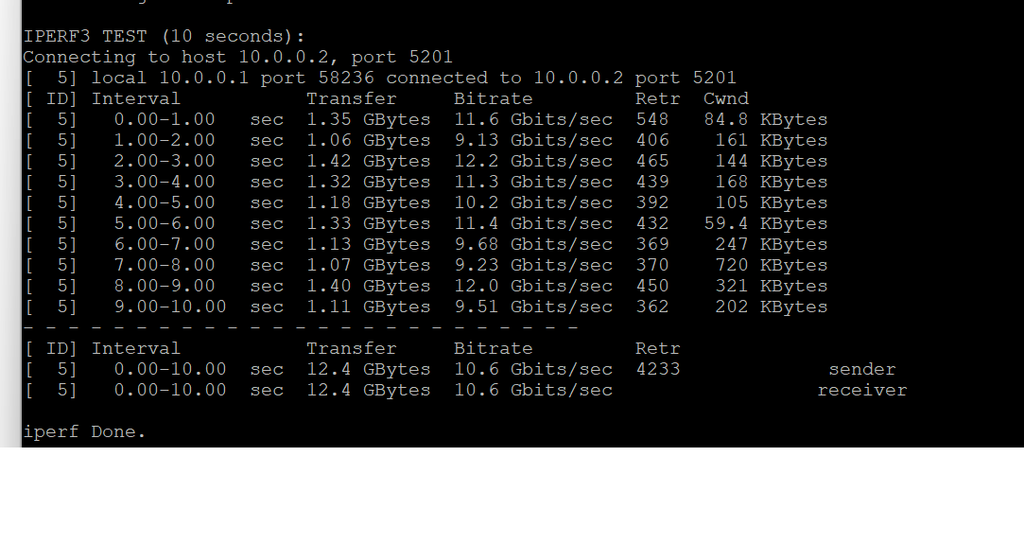

Запуск lab_netem_corruption.py

## Выводы

Получил навыки проведения интерактивных экспериментов в среде Mininet по исследованию параметров сети, связанных с потерей, дублированием, изменением порядка и повреждением пакетов при передаче данных.